# Plan prezentacji

1. Hipoteza
2. Opis trackera Fitbit
3. Opis danych
4. Analiza stacjonarności szeregów czasowych
5. Dekompozycja szeregu czasowego
6. Analiza korelacji
7. Podsumowanie wyników

## Badana hipoteza

# Czy jestem meteoropatką?

[figure not shown]

Za: Słownik języka polskiego pod red. W. Doroszewskiego, 1958 r.

# Tracker - Fitbit Alta HR

[figure not shown]

# Jakich danych dostarcza Fitbit?

- Liczba kroków, pięter na które się weszło, przebytych kilometrów.
- Liczba spalonych kalorii w ciągu dnia.
- Tętno spoczynkowe, tętno w danym momencie.
- Długość i jakość snu.

Dane pochodzą z czujników:

- Akcelerometru
- Barometru
- Żyroskopu
- Fotoplezmatografu

Nie mamy dostępu do bezpośredniego sygnału z czujników z poziomu Web API.

# Fotopletyzmografia (PPG)

[figure not shown]

Metoda optycznego pomiaru zmian przepływu krwi przez naczynia obwodowe położone blisko powierzchni ciała, może być stosowana do pomiaru szybkości pracy serca.

Fitbit używa zielonych LEDów i fotodiody do pomiaru odbijanego światła, a dzięki temu pojemności naczyń krwionośnych pod skórą.

```
Pierwszy dzień:  2018-07-11 00:00:00
Ostatni dzień:  2018-10-31 00:00:00
Minimalne tętno:  67.0
Maksymalne tętno:  77.0
```

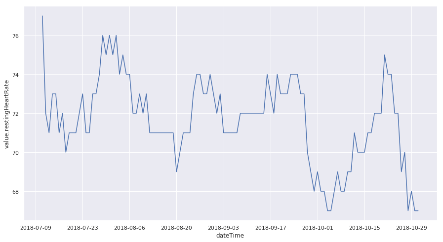

```python
sns.lineplot(x=rhr_daily.index, y="value.restingHeartRate", data=rhr_daily)
print("Pierwszy dzień: ", rhr_daily.index.min())
print("Ostatni dzień: ", rhr_daily.index.max())
print("Minimalne tętno: ", rhr_daily["value.restingHeartRate"].min())
print("Maksymalne tętno: ", rhr_daily["value.restingHeartRate"].max())
```

```python
sleep_sources = ["data/sleep-2018-07-11-2018-09-30.json", "data/sleep-2018-10-01-2018-10-31.json"]
sleep = load_json(sleep_sources, "sleep")
data_all, data_sleep, data_naps = format_sleep(sleep)
data_sleep = remove_constant_cols(data_sleep)
data_sleep.info()
```

```
<class 'pandas.core.frame.DataFrame'>
DatetimeIndex: 108 entries, 2018-07-12 to 2018-10-31
Data columns (total 22 columns):
duration                                    108 non-null int64
efficiency                                  108 non-null int64
endTime                                     108 non-null datetime64[ns]
levels.summary.deep.count                   108 non-null float64
levels.summary.deep.minutes                 108 non-null float64
levels.summary.deep.thirtyDayAvgMinutes     108 non-null float64
levels.summary.light.count                  108 non-null float64
levels.summary.light.minutes                108 non-null float64
levels.summary.light.thirtyDayAvgMinutes    108 non-null float64
levels.summary.rem.count                    108 non-null float64
levels.summary.rem.minutes                  108 non-null float64
levels.summary.rem.thirtyDayAvgMinutes      108 non-null float64
levels.summary.wake.count                   108 non-null float64
levels.summary.wake.minutes                 108 non-null float64
levels.summary.wake.thirtyDayAvgMinutes     108 non-null float64
minutesAfterWakeup                          108 non-null int64
minutesAsleep                               108 non-null int64
minutesAwake                                108 non-null int64
startTime                                   108 non-null datetime64[ns]
timeInBed                                   108 non-null int64
weekday                                     108 non-null int64
dayOfWeek                                   108 non-null object
dtypes: datetime64[ns](2), float64(12), int64(7), object(1)
memory usage: 19.4+ KB
```

```
Minimalna efektywność snu:  87
Maksymalna efektywność snu:  100
```

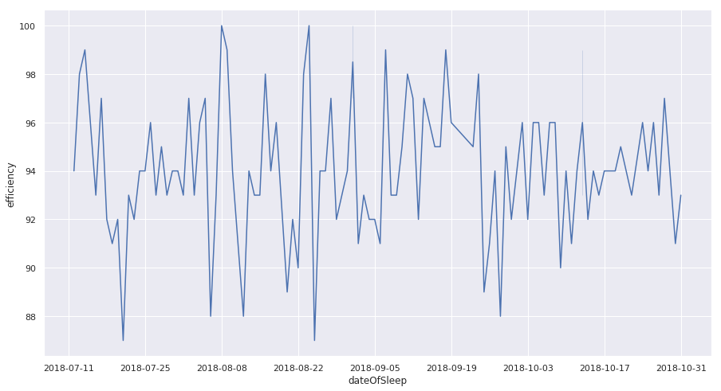

```python
print("Minimalna efektywność snu: ", data_sleep["efficiency"].min())
print("Maksymalna efektywność snu: ", data_sleep["efficiency"].max())
sns.lineplot(data_sleep.index, data_sleep["efficiency"])
```

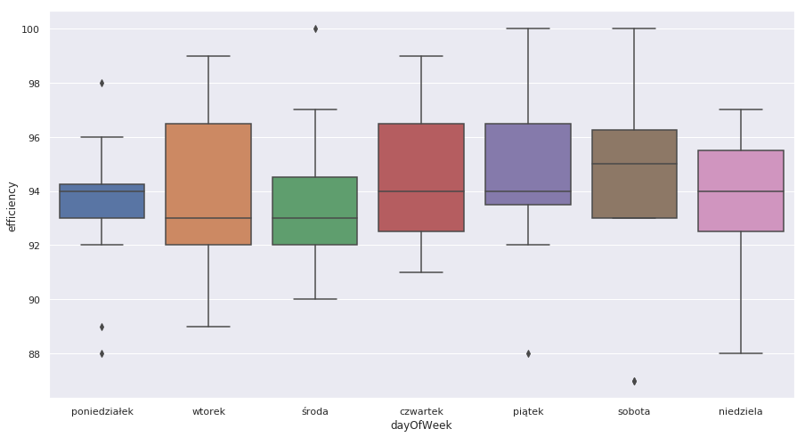

```python
sns.boxplot(x="dayOfWeek", y="efficiency", data=data_sleep, order=WEEKDAYS)
```

# Dane meteorologiczne pochodzą ze strony meteomodel.pl

[figure not shown]

```python
meteo_daily = pd.read_csv("data/Dane meteorologiczne.csv", index_col=[0], parse_dates=[0])
meteo_daily = meteo_daily.fillna(0)
meteo_daily.info()
```

```
<class 'pandas.core.frame.DataFrame'>
DatetimeIndex: 113 entries, 2018-07-11 to 2018-10-31
Data columns (total 17 columns):
Średnia temperatura powietrza                   113 non-null float64
Maksymalna temperatura powietrza                113 non-null float64
Minimalna temperatura powietrza                 113 non-null float64
Minimalna temperatura powietrza przy gruncie    113 non-null float64
Średnia wilgotność powietrza                    113 non-null float64
Średnia prężność pary wodnej                    113 non-null float64
Średnie zachmurzenie                            113 non-null float64
Średnia prędkość wiatru                         113 non-null float64
Ciśnienie na poziomie morza                     113 non-null float64
Ciśnienie na poziomie stacji                    113 non-null float64
Dobowa suma opadu                               113 non-null float64
Opad - dzień                                    113 non-null float64
Opad - noc                                      113 non-null float64
Usłonecznienie                                  113 non-null float64
Czas trwania opadu deszczu                      113 non-null float64
Czas trwania rosy                               113 non-null float64
Czas trwania burzy                              113 non-null float64
dtypes: float64(17)
memory usage: 15.9 KB
```

# Czy wszystkie analizowane szeregi są stacjonarne?

Stacjonarny szereg czasowy - szereg w którym wartość średnia, wariancja oraz funkcja autokorelacji nie zmieniają się wraz ze zmianą czasu.

[figure not shown]

# Rozszerzony test Dickeya-Fullera (Augmented Dickey-Fuller test)

Test statystyczny, polegający na próbie dopasowania do danych modelu autoregresyjnego, uwzględniający dwie hipotezy:

- $H_0$: Szereg jest niestacjonarny.
- $H_1$: Szereg jest stacjonarny.

Przy wyniku $ p-value < 0.05 $ hipoteza zerowa jest odrzucana - szereg jest stacjonarny.

```python
import statsmodels.tsa.stattools as ts
rhr_series = rhr_daily["value.restingHeartRate"].values
result = ts.adfuller(rhr_series)
print("Wynik testu dla tętna spoczynkowego\np-value: {:.24f}".format(result[1]))

sleep_series = data_sleep["efficiency"].fillna(0).values
result = ts.adfuller(sleep_series)
print("Wynik testu dla efektywności snu\np-value: {:.24f}".format(result[1]))
```

```
Wynik testu dla tętna spoczynkowego
p-value: 0.026188396618426579981476
Wynik testu dla efektywności snu
p-value: 0.000000000019042035089119
```

```python
meteo_adf = np.zeros(len(meteo_daily.columns))

for i, column in enumerate(meteo_daily.columns):
    meteo_series = meteo_daily[column].fillna(0).values
    adf = ts.adfuller(meteo_series)[1]
    meteo_adf[i] = adf

meteo_adf_df = pd.DataFrame(meteo_adf, index=meteo_daily.columns,
                            columns=["p-value"])
meteo_adf_df.sort_values(by="p-value", ascending=False, inplace=True)
meteo_adf_df.style.format("{:.6f}")
```

|  | p-value |
| --- | --- |
| Minimalna temperatura powietrza przy gruncie | 0.867639 |
| Minimalna temperatura powietrza | 0.859623 |
| Średnia prężność pary wodnej | 0.699345 |
| Średnia temperatura powietrza | 0.614118 |
| Maksymalna temperatura powietrza | 0.395975 |
| Czas trwania burzy | 0.017540 |
| Ciśnienie na poziomie morza | 0.004599 |
| Ciśnienie na poziomie stacji | 0.003533 |
| Średnia wilgotność powietrza | 0.001089 |
| Czas trwania opadu deszczu | 0.000424 |
| Średnie zachmurzenie | 0.000000 |
| Usłonecznienie | 0.000000 |
| Średnia prędkość wiatru | 0.000000 |
| Czas trwania rosy | 0.000000 |
| Opad - dzień | 0.000000 |
| Dobowa suma opadu | 0.000000 |
| Opad - noc | 0.000000 |

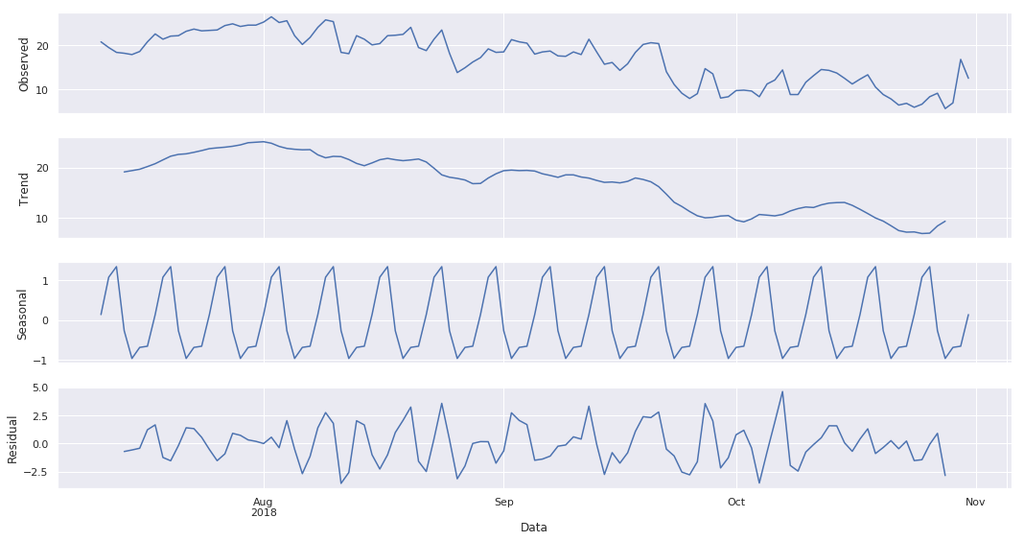

```python
from statsmodels.tsa.seasonal import seasonal_decompose

def meteo_decompose(dataset, column):
    result = seasonal_decompose(meteo_daily[column], model="additive", )
    meteo_daily[column + " - resid"] = result.resid
    meteo_daily.drop(column, axis=1, inplace=True)
    return dataset, result

meteo_daily, result = meteo_decompose(meteo_daily, "Średnia temperatura powietrza")
result.plot()
pyplot.show()
```